# Exploratory analysis Airbnb Kaggle Competition

by Timotius Andrean Patrick Lagaunne

# LIBRARY

[output not shown]

# General Overview of Data

```r
setwd("/home/lagaunne/Patrick/Back Up/Document/R/Kaggle/Airbnb")
airbnb<-read.csv("train_users_2.csv",na.strings=c("","NA"))

summary(airbnb)
```

```
##           id         date_account_created timestamp_first_active
##  00023iyk9l:     1   2014-05-13:   674    Min.   :2.009e+13
##  0005ytdols:     1   2014-06-24:   670    1st Qu.:2.012e+13
##  000guo2307:     1   2014-06-25:   636    Median :2.013e+13
##  000wc9mlv3:     1   2014-05-20:   632    Mean   :2.013e+13
##  0012yo8hu2:     1   2014-05-14:   622    3rd Qu.:2.014e+13
##  001357912w:     1   2014-05-21:   602    Max.   :2.014e+13
##  (Other)   :213445   (Other)   :209615
##   date_first_booking       gender           age           signup_method
##  2014-05-22:   248   FEMALE   :63041   Min.   :   1.00   basic   :152897
##  2014-06-11:   231   MALE     :54440   1st Qu.:  28.00   facebook: 60008
##  2014-06-24:   226   OTHER    :  282   Median :  34.00   google  :   546
##  2014-05-21:   225   -unknown-:95688   Mean   :  49.67
##  2014-06-10:   223                     3rd Qu.:  43.00
##  (Other)   : 87755                     Max.   :2014.00
##  NA's      :124543                     NA's   :87990
##   signup_flow        language          affiliate_channel
##  Min.   : 0.000   en     :206314   direct       :137727
##  1st Qu.: 0.000   zh     :  1632   sem-brand    : 26045
##  Median : 0.000   fr     :  1172   sem-non-brand: 18844
##  Mean   : 3.267   es     :   915   other        :  8961
##  3rd Qu.: 0.000   ko     :   747   seo          :  8663
##  Max.   :25.000   de     :   732   api          :  8167
##                   (Other):  1939   (Other)      :  5044
##   affiliate_provider  first_affiliate_tracked   signup_app
##  direct    :137426   untracked    :109232     Android:  5454
##  google    : 51693   linked       : 46287     iOS    : 19019
##  other     : 12549   omg          : 43982     Moweb  :  6261
##  craigslist:  3471   tracked-other:  6156     Web    :182717
##  bing      :  2328   product      :  1556
##  facebook  :  2273   (Other)      :   173
##  (Other)   :  3711   NA's         :  6065
##        first_device_type       first_browser   country_destination
##  Mac Desktop    :89600   Chrome       :63845   NDF    :124543
##  Windows Desktop:72716   Safari       :45169   US     : 62376
##  iPhone         :20759   Firefox      :33655   other  : 10094
##  iPad           :14339   -unknown-    :27266   FR     :  5023
##  Other/Unknown  :10667   IE           :21068   IT     :  2835
##  Android Phone  : 2803   Mobile Safari:19274   GB     :  2324
##  (Other)        : 2567   (Other)      : 3174   (Other):  6256
```

```r
head(airbnb)
```

```
##           id date_account_created timestamp_first_active
## 1 gxn3p5htnn           2010-06-28           2.009032e+13
## 2 820tgsjxq7           2011-05-25           2.009052e+13
## 3 4ft3gnwmtx           2010-09-28           2.009061e+13
## 4 bjjt8pjhuk           2011-12-05           2.009103e+13
## 5 87mebub9p4           2010-09-14           2.009121e+13
## 6 osr2jwljor           2010-01-01           2.010010e+13
##   date_first_booking    gender age signup_method signup_flow language
## 1               <NA> -unknown-  NA      facebook           0       en
## 2               <NA>      MALE  38      facebook           0       en
## 3         2010-08-02    FEMALE  56         basic           3       en
## 4         2012-09-08    FEMALE  42      facebook           0       en
## 5         2010-02-18 -unknown-  41         basic           0       en
## 6         2010-01-02 -unknown-  NA         basic           0       en
##   affiliate_channel affiliate_provider first_affiliate_tracked signup_app
## 1            direct             direct               untracked        Web
## 2               seo             google               untracked        Web
## 3            direct             direct               untracked        Web
## 4            direct             direct               untracked        Web
## 5            direct             direct               untracked        Web
## 6             other              other                     omg        Web
##   first_device_type first_browser country_destination
## 1       Mac Desktop        Chrome                 NDF
## 2       Mac Desktop        Chrome                 NDF
## 3   Windows Desktop            IE                  US
## 4       Mac Desktop       Firefox               other
## 5       Mac Desktop        Chrome                  US
## 6       Mac Desktop        Chrome                  US
```

```r
tail(airbnb)
```

```
##                id date_account_created timestamp_first_active
## 213446 qbxza0xojf           2014-06-30           2.014063e+13
## 213447 zxodksqpep           2014-06-30           2.014063e+13
## 213448 mhewnxesx9           2014-06-30           2.014063e+13
## 213449 6o3arsjbb4           2014-06-30           2.014063e+13
## 213450 jh95kwisub           2014-06-30           2.014063e+13
## 213451 nw9fwlyb5f           2014-06-30           2.014063e+13
##        date_first_booking    gender age signup_method signup_flow language
## 213446         2014-07-02    FEMALE  23         basic           0       en
## 213447               <NA>      MALE  32         basic           0       en
## 213448               <NA> -unknown-  NA         basic           0       en
## 213449               <NA> -unknown-  32         basic           0       en
## 213450               <NA> -unknown-  NA         basic          25       en
## 213451               <NA> -unknown-  NA         basic          25       en
##        affiliate_channel affiliate_provider first_affiliate_tracked
## 213446         sem-brand             google                     omg
## 213447         sem-brand             google                     omg
## 213448            direct             direct                  linked
## 213449            direct             direct               untracked
## 213450             other              other           tracked-other
## 213451            direct             direct               untracked
##        signup_app first_device_type first_browser country_destination
## 213446        Web   Windows Desktop            IE                  US
## 213447        Web       Mac Desktop        Safari                 NDF
## 213448        Web   Windows Desktop        Chrome                 NDF
## 213449        Web       Mac Desktop       Firefox                 NDF
## 213450        iOS            iPhone Mobile Safari                 NDF
## 213451        iOS            iPhone     -unknown-                 NDF
```

```r
str(airbnb)
```

```
## 'data.frame':    213451 obs. of  16 variables:
##  $ id                     : Factor w/ 213451 levels "00023iyk9l","0005ytdols",..: 100523 48039 26485 68504 48956 147281 129610 2144 59779 40826 ...
##  $ date_account_created   : Factor w/ 1634 levels "2010-01-01","2010-01-02",..: 171 502 263 696 249 1 2 3 4 4 ...
##  $ timestamp_first_active : num  2.01e+13 2.01e+13 2.01e+13 2.01e+13 2.01e+13 ...
##  $ date_first_booking     : Factor w/ 1976 levels "2010-01-02","2010-01-04",..: NA NA 193 959 34 1 3 9 189 2 ...
##  $ gender                 : Factor w/ 4 levels "FEMALE","MALE",..: 4 2 1 1 4 4 1 1 1 4 ...
##  $ age                    : num  NA 38 56 42 41 NA 46 47 50 46 ...
##  $ signup_method          : Factor w/ 3 levels "basic","facebook",..: 2 2 1 2 1 1 1 1 1 1 ...
##  $ signup_flow            : int  0 0 3 0 0 0 0 0 0 0 ...
##  $ language               : Factor w/ 25 levels "ca","cs","da",..: 6 6 6 6 6 6 6 6 6 6 ...
##  $ affiliate_channel      : Factor w/ 8 levels "api","content",..: 3 8 3 3 3 4 4 3 4 4 ...
##  $ affiliate_provider     : Factor w/ 18 levels "baidu","bing",..: 5 9 5 5 5 13 3 5 3 3 ...
##  $ first_affiliate_tracked: Factor w/ 7 levels "linked","local ops",..: 7 7 7 7 7 4 7 4 7 4 ...
##  $ signup_app             : Factor w/ 4 levels "Android","iOS",..: 4 4 4 4 4 4 4 4 4 4 ...
##  $ first_device_type      : Factor w/ 9 levels "Android Phone",..: 6 6 9 6 6 6 6 6 6 6 ...
##  $ first_browser          : Factor w/ 52 levels "Android Browser",..: 8 8 23 17 8 8 41 41 41 17 ...
##  $ country_destination    : Factor w/ 12 levels "AU","CA","DE",..: 8 8 12 10 12 12 12 12 12 12 ...
```

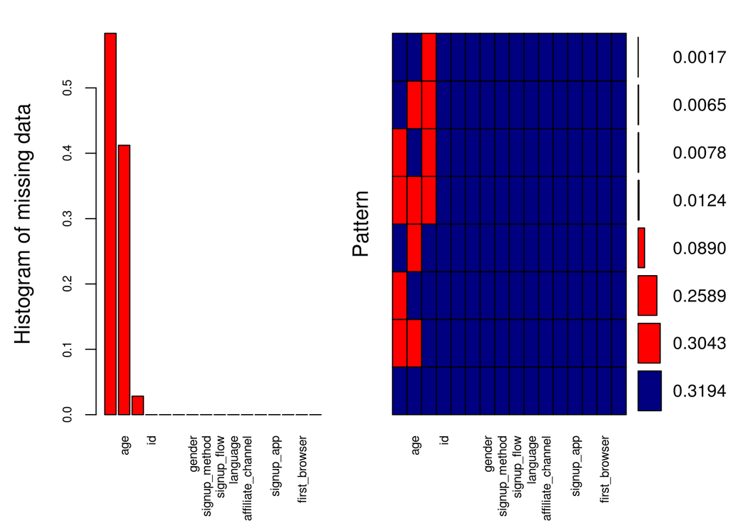

```
##
##  Variables sorted by number of missings:
##                 Variable      Count
##       date_first_booking 0.58347349
##                      age 0.41222576
##  first_affiliate_tracked 0.02841402
##                       id 0.00000000
##     date_account_created 0.00000000
##   timestamp_first_active 0.00000000
##                   gender 0.00000000
##            signup_method 0.00000000
##              signup_flow 0.00000000
##                 language 0.00000000
##        affiliate_channel 0.00000000
##       affiliate_provider 0.00000000
##               signup_app 0.00000000
##        first_device_type 0.00000000
##            first_browser 0.00000000
##      country_destination 0.00000000
```

```r
##Missing data
aggr_plot <- aggr(airbnb, col=c('navyblue','red'), numbers=TRUE, sortVars=TRUE, labels=names(airbnb), cex.axis=.7, gap=3, ylab=c("Histogram of missing data","Pattern"))
```

*There are several things that we need to concern based on the overview of the data. +The timestamp_first_active variable is not in the right format. +The signup_flow variable is better to be factor type +The age variable has “NA” value and age value of 2014 which is impossible for age variable +The date first booking has missing values +The first_affiliate_tracked has missing values +the weight is different for different output of country_destination

## Data Cleaning and Manipulation

### timestamp_first_active

```r
airbnb$timestamp_first_active <- ymd_hms(airbnb$timestamp_first_active)
##unclass the timestamp variable
```

### age

```r
##outlier taken out
airbnb$age[airbnb$age>100]=NA
airbnb$age[airbnb$age<14]=NA
airbnb$age<-as.integer(airbnb$age)
##missing value imputation with the mean
airbnb$age[is.na(airbnb$age)]=mean(airbnb$age,na.rm=TRUE)
```

### sign

```r
###change the variable into factor type
airbnb$signup_flow<-as.factor(airbnb$signup_flow)
```

# Overview of Data Again

```r
summary(airbnb)
```

```
##           id         date_account_created timestamp_first_active
##  00023iyk9l:     1   2014-05-13:   674    Min.   :2009-03-19 04:32:55
##  0005ytdols:     1   2014-06-24:   670    1st Qu.:2012-12-25 07:33:27
##  000guo2307:     1   2014-06-25:   636    Median :2013-09-11 06:13:08
##  000wc9mlv3:     1   2014-05-20:   632    Mean   :2013-06-25 16:15:47
##  0012yo8hu2:     1   2014-05-14:   622    3rd Qu.:2014-03-06 08:25:14
##  001357912w:     1   2014-05-21:   602    Max.   :2014-06-30 23:58:24
##  (Other)   :213445   (Other)   :209615
##   date_first_booking       gender           age          signup_method
##  2014-05-22:   248   FEMALE   :63041   Min.   : 15.00   basic   :152897
##  2014-06-11:   231   MALE     :54440   1st Qu.: 32.00   facebook: 60008
##  2014-06-24:   226   OTHER    :  282   Median : 36.56   google  :   546
##  2014-05-21:   225   -unknown-:95688   Mean   : 36.56
##  2014-06-10:   223                     3rd Qu.: 36.56
##  (Other)   : 87755                     Max.   :100.00
##  NA's      :124543
##   signup_flow        language          affiliate_channel
##  0      :164739   en     :206314   direct       :137727
##  25     : 14659   zh     :  1632   sem-brand    : 26045
##  12     :  9329   fr     :  1172   sem-non-brand: 18844
##  3      :  8822   es     :   915   other        :  8961
##  2      :  6881   ko     :   747   seo          :  8663
##  24     :  4328   de     :   732   api          :  8167
##  (Other):  4693   (Other):  1939   (Other)      :  5044
##   affiliate_provider  first_affiliate_tracked   signup_app
##  direct    :137426   untracked    :109232     Android:  5454
##  google    : 51693   linked       : 46287     iOS    : 19019
##  other     : 12549   omg          : 43982     Moweb  :  6261
##  craigslist:  3471   tracked-other:  6156     Web    :182717
##  bing      :  2328   product      :  1556
##  facebook  :  2273   (Other)      :   173
##  (Other)   :  3711   NA's         :  6065
##        first_device_type       first_browser   country_destination
##  Mac Desktop    :89600   Chrome       :63845   NDF    :124543
##  Windows Desktop:72716   Safari       :45169   US     : 62376
##  iPhone         :20759   Firefox      :33655   other  : 10094
##  iPad           :14339   -unknown-    :27266   FR     :  5023
##  Other/Unknown  :10667   IE           :21068   IT     :  2835
##  Android Phone  : 2803   Mobile Safari:19274   GB     :  2324
##  (Other)        : 2567   (Other)      : 3174   (Other):  6256
```

```r
str(airbnb)
```

```
## 'data.frame':    213451 obs. of  16 variables:
##  $ id                     : Factor w/ 213451 levels "00023iyk9l","0005ytdols",..: 100523 48039 26485 68504 48956 147281 129610 2144 59779 40826 ...
##  $ date_account_created   : Factor w/ 1634 levels "2010-01-01","2010-01-02",..: 171 502 263 696 249 1 2 3 4 4 ...
##  $ timestamp_first_active : POSIXct, format: "2009-03-19 04:32:55" "2009-05-23 17:48:09" ...
##  $ date_first_booking     : Factor w/ 1976 levels "2010-01-02","2010-01-04",..: NA NA 193 959 34 1 3 9 189 2 ...
##  $ gender                 : Factor w/ 4 levels "FEMALE","MALE",..: 4 2 1 1 4 4 1 1 1 4 ...
##  $ age                    : num  36.6 38 56 42 41 ...
##  $ signup_method          : Factor w/ 3 levels "basic","facebook",..: 2 2 1 2 1 1 1 1 1 1 ...
##  $ signup_flow            : Factor w/ 17 levels "0","1","2","3",..: 1 1 4 1 1 1 1 1 1 1 ...
##  $ language               : Factor w/ 25 levels "ca","cs","da",..: 6 6 6 6 6 6 6 6 6 6 ...
##  $ affiliate_channel      : Factor w/ 8 levels "api","content",..: 3 8 3 3 3 4 4 3 4 4 ...
##  $ affiliate_provider     : Factor w/ 18 levels "baidu","bing",..: 5 9 5 5 5 13 3 5 3 3 ...
##  $ first_affiliate_tracked: Factor w/ 7 levels "linked","local ops",..: 7 7 7 7 7 4 7 4 7 4 ...
##  $ signup_app             : Factor w/ 4 levels "Android","iOS",..: 4 4 4 4 4 4 4 4 4 4 ...
##  $ first_device_type      : Factor w/ 9 levels "Android Phone",..: 6 6 9 6 6 6 6 6 6 6 ...
##  $ first_browser          : Factor w/ 52 levels "Android Browser",..: 8 8 23 17 8 8 41 41 41 17 ...
##  $ country_destination    : Factor w/ 12 levels "AU","CA","DE",..: 8 8 12 10 12 12 12 12 12 12 ...
```

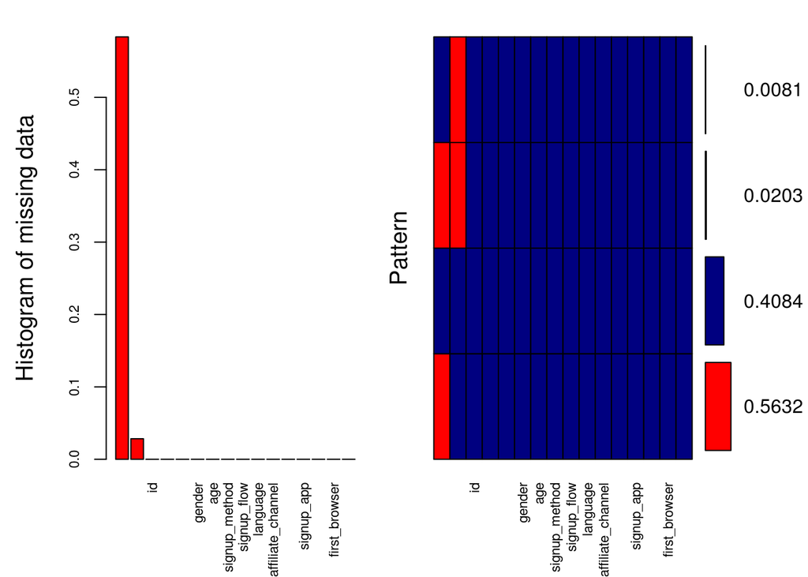

```
##
##  Variables sorted by number of missings:
##                 Variable      Count
##       date_first_booking 0.58347349
##  first_affiliate_tracked 0.02841402
##                       id 0.00000000
##     date_account_created 0.00000000
##   timestamp_first_active 0.00000000
##                   gender 0.00000000
##                      age 0.00000000
##            signup_method 0.00000000
##              signup_flow 0.00000000
##                 language 0.00000000
##        affiliate_channel 0.00000000
##       affiliate_provider 0.00000000
##               signup_app 0.00000000
##        first_device_type 0.00000000
##            first_browser 0.00000000
##      country_destination 0.00000000
```

```r
##Missing data
aggr_plot <- aggr(airbnb, col=c('navyblue','red'), numbers=TRUE, sortVars=TRUE, labels=names(airbnb), cex.axis=.7, gap=3, ylab=c("Histogram of missing data","Pattern"))
```

Going through the overview of data again, The the date_first_booking variable still has missing value, but the missing value happen because the registered user has not book in airbnb so the missing value is fine. The first_affiliate_tracked are also not very significant so its fine to keep it as it is. The only thing that need to be solve still is the weight which can be solve with sampling adjustment with bootstraping

## Sampling Adjustment

```r
###Re-adjusting the weight of data by bootstraping
A<-group_by(airbnb,country_destination)
airbnb<-sample_n(A,30000,replace=TRUE)
```

## Data Exploratory

### date_account created

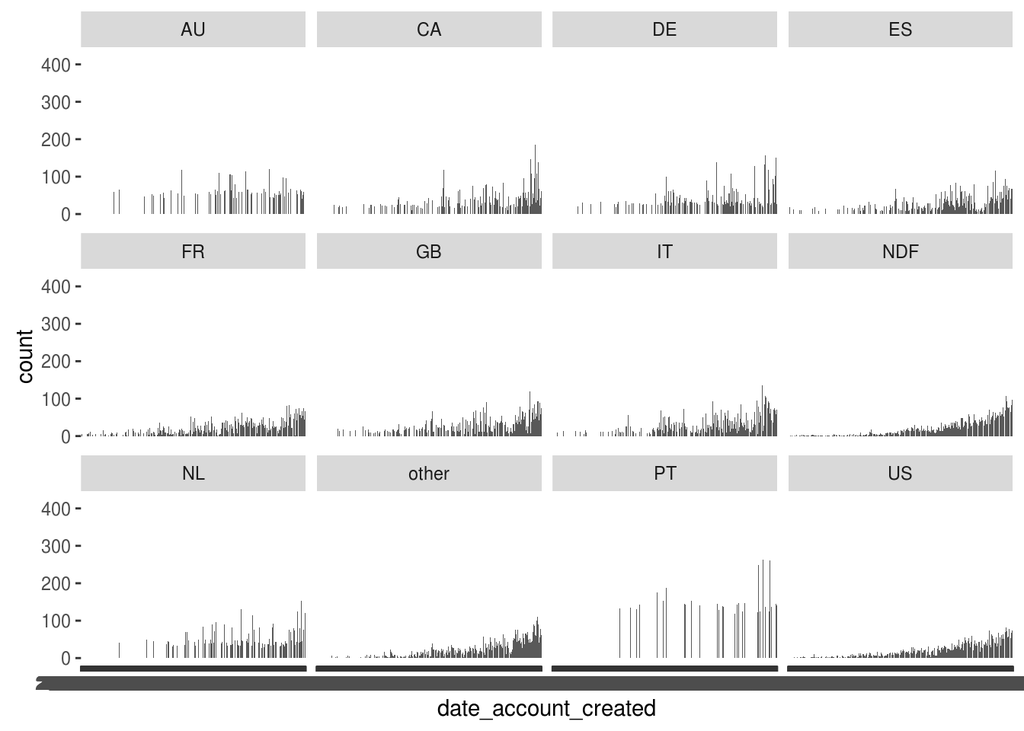

### timestamp_first_active

```r
newunclasstimestamp<-unclass(as.POSIXlt(airbnb$timestamp_first_active))
temp=data.frame(newunclasstimestamp)
newtimestamp<-cbind(temp,airbnb$country_destination)
newtimestamp<-data.frame(newtimestamp)
airbnb<-cbind(airbnb,newtimestamp$hour,newtimestamp$mon)
summary(newtimestamp)
```

```
##       sec             min             hour            mday
##  Min.   : 0.00   Min.   : 0.00   Min.   : 0.00   Min.   : 1.00
##  1st Qu.:15.00   1st Qu.:14.00   1st Qu.: 4.00   1st Qu.: 8.00
##  Median :29.00   Median :29.00   Median :15.00   Median :16.00
##  Mean   :29.42   Mean   :29.37   Mean   :12.24   Mean   :15.82
##  3rd Qu.:44.00   3rd Qu.:45.00   3rd Qu.:19.00   3rd Qu.:23.00
##  Max.   :59.00   Max.   :59.00   Max.   :23.00   Max.   :31.00
##
##       mon              year            wday            yday
##  Min.   : 0.000   Min.   :109.0   Min.   :0.000   Min.   :  0.0
##  1st Qu.: 3.000   1st Qu.:112.0   1st Qu.:1.000   1st Qu.: 91.0
##  Median : 5.000   Median :113.0   Median :3.000   Median :154.0
##  Mean   : 4.951   Mean   :112.9   Mean   :2.922   Mean   :164.7
##  3rd Qu.: 7.000   3rd Qu.:114.0   3rd Qu.:4.000   3rd Qu.:238.0
##  Max.   :11.000   Max.   :114.0   Max.   :6.000   Max.   :365.0
##
##      isdst   airbnb.country_destination
##  Min.   :0   AU     : 30000
##  1st Qu.:0   CA     : 30000
##  Median :0   DE     : 30000
##  Mean   :0   ES     : 30000
##  3rd Qu.:0   FR     : 30000
##  Max.   :0   GB     : 30000
##              (Other):180000
```

```r
str(newtimestamp)
```

```
## 'data.frame':    360000 obs. of  10 variables:
##  $ sec                       : num  59 18 18 57 34 24 56 3 59 0 ...
##  $ min                       : int  34 53 24 30 28 14 52 9 37 57 ...
##  $ hour                      : int  21 14 17 20 19 21 6 0 5 21 ...
##  $ mday                      : int  18 12 8 8 25 9 26 16 20 21 ...
##  $ mon                       : int  4 7 8 7 4 1 5 10 8 7 ...
##  $ year                      : int  111 113 113 113 114 114 114 111 112 113 ...
##  $ wday                      : int  3 1 0 4 0 0 4 3 4 3 ...
##  $ yday                      : int  137 223 250 219 144 39 176 319 263 232 ...
##  $ isdst                     : int  0 0 0 0 0 0 0 0 0 0 ...
##  $ airbnb.country_destination: Factor w/ 12 levels "AU","CA","DE",..: 1 1 1 1 1 1 1 1 1 1 ...
```

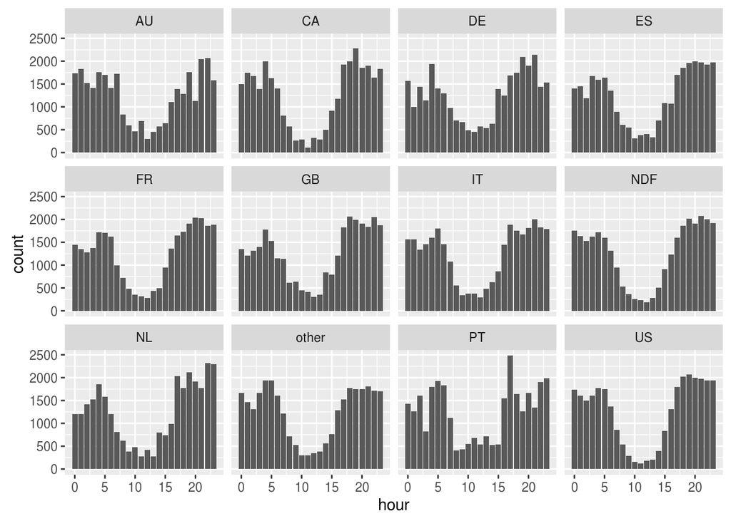

```r
### Among the variable the only one that need to be use most likely is the hour and month because hour can specified the user place and the month can give seasonal feature
ggplot(data=newtimestamp,aes(hour))+geom_bar()+facet_wrap(~airbnb.country_destination)
```

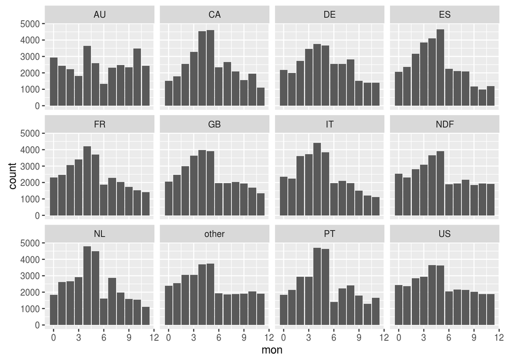

```r
ggplot(data=newtimestamp,aes(mon))+geom_bar()+facet_wrap(~airbnb.country_destination)
```

### date_first_booking

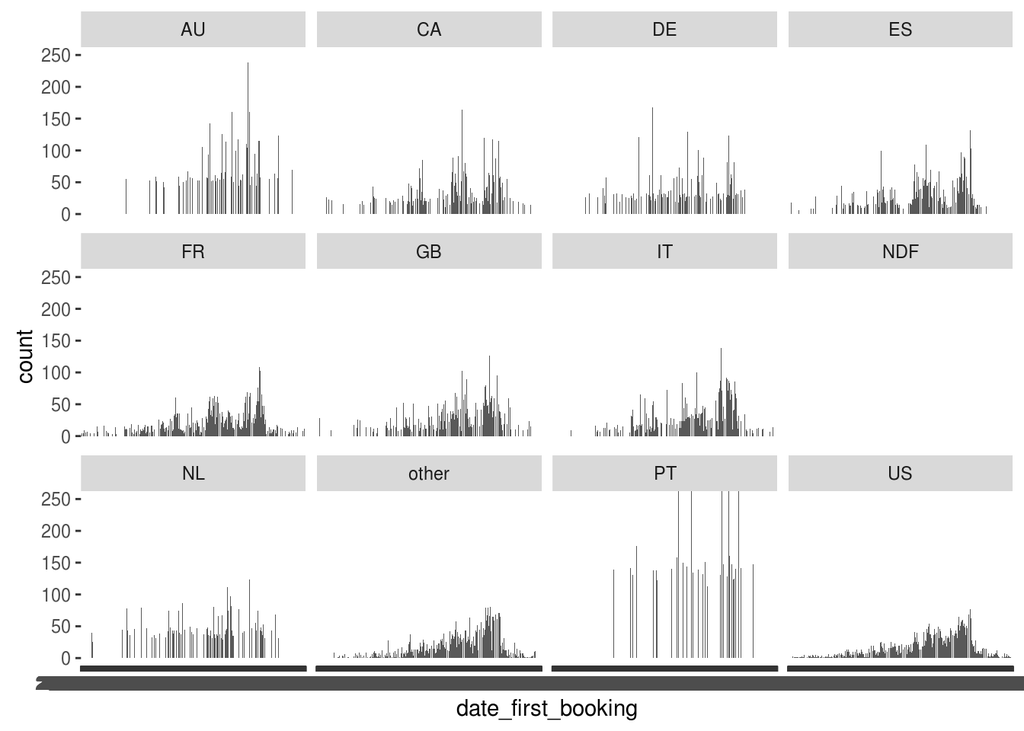

### gender

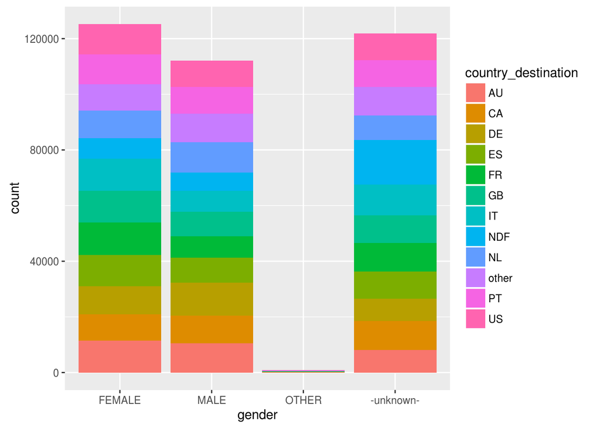

### age

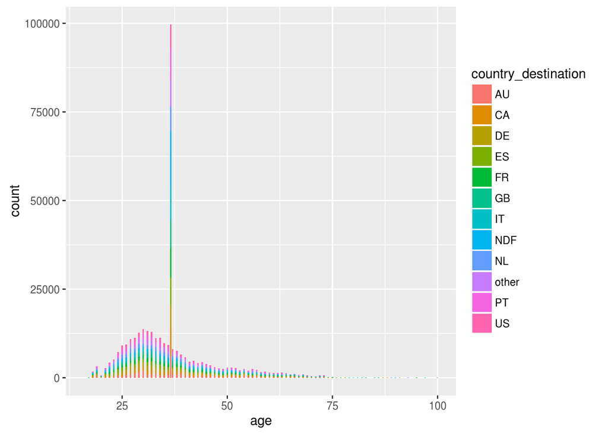

### signup_method

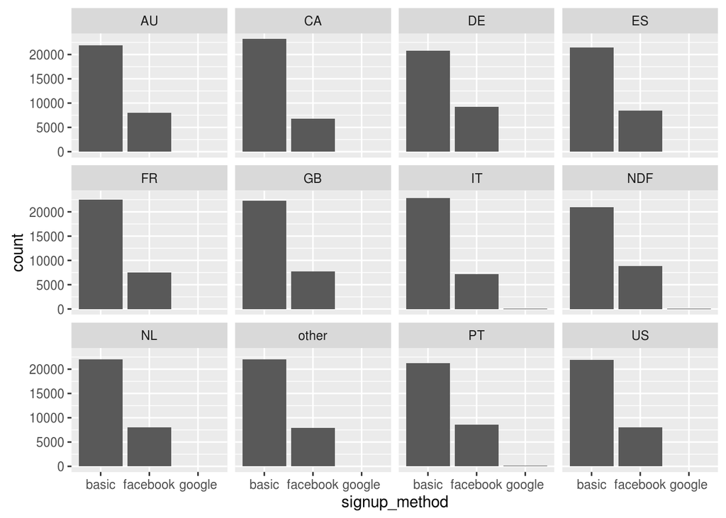

### signup_flow

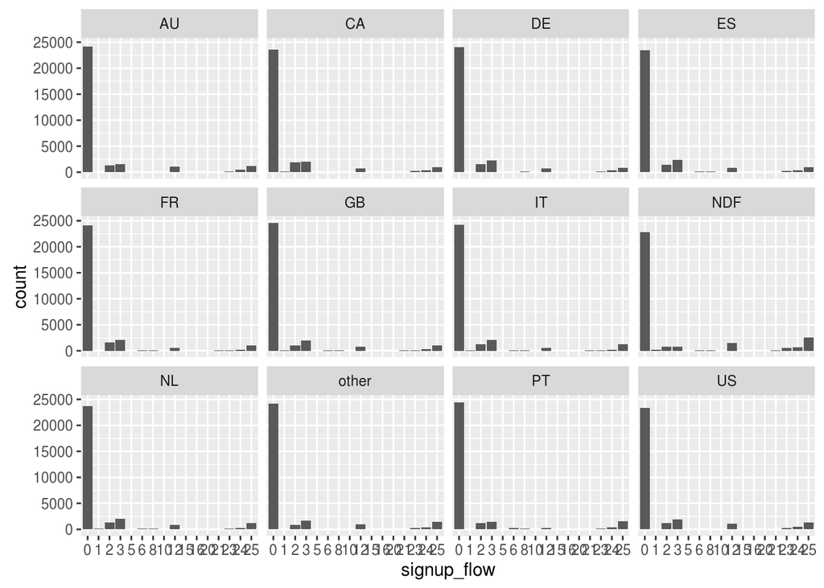

### language

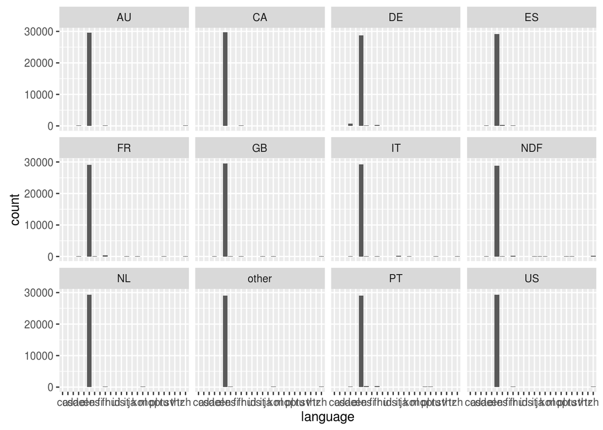

### affiliate_channel

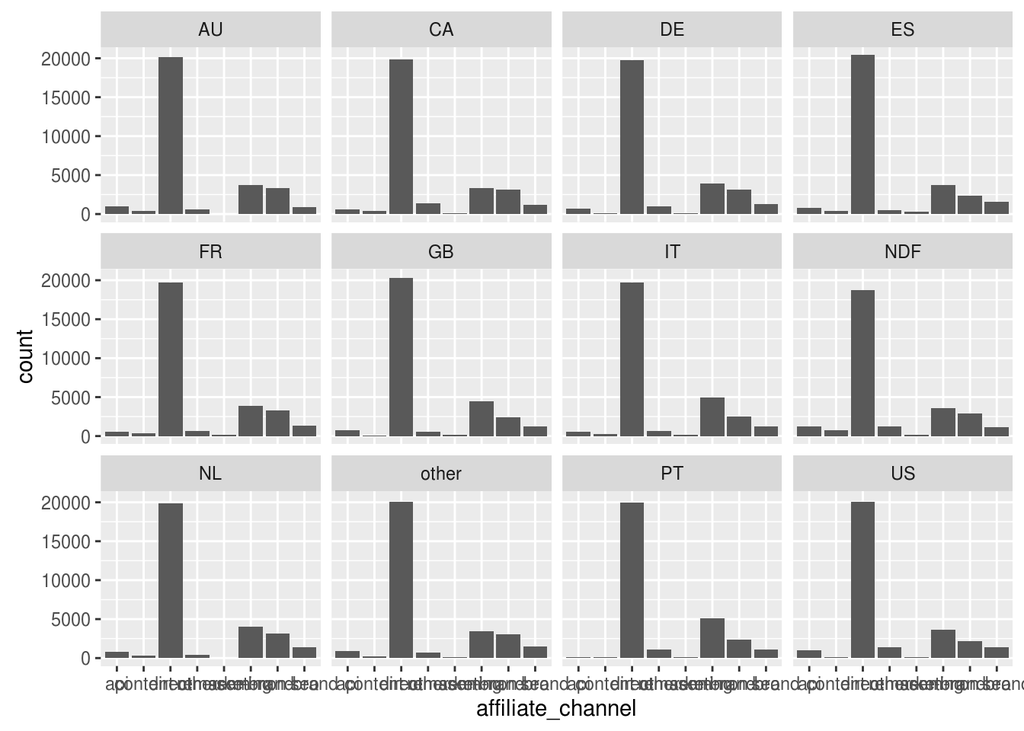

### affiliate_provider

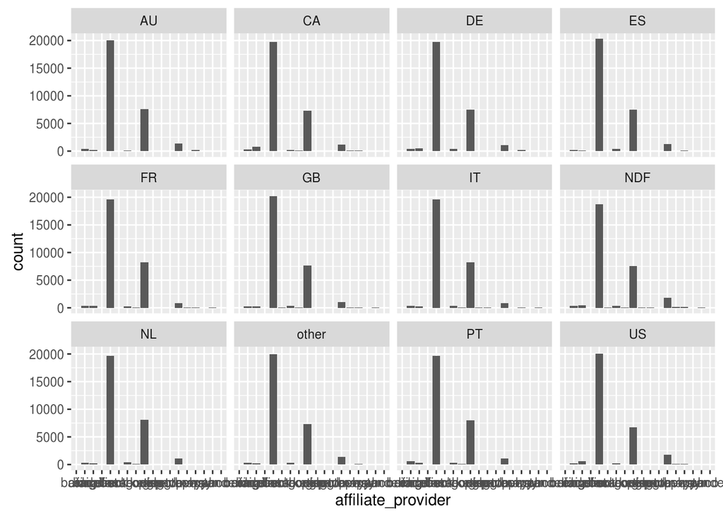

### first_affiliate_tracked

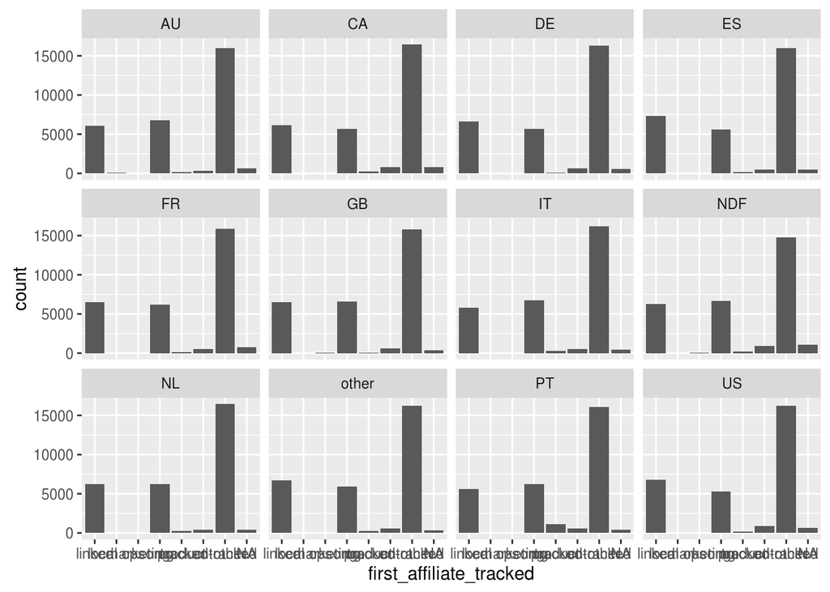

### signup_app

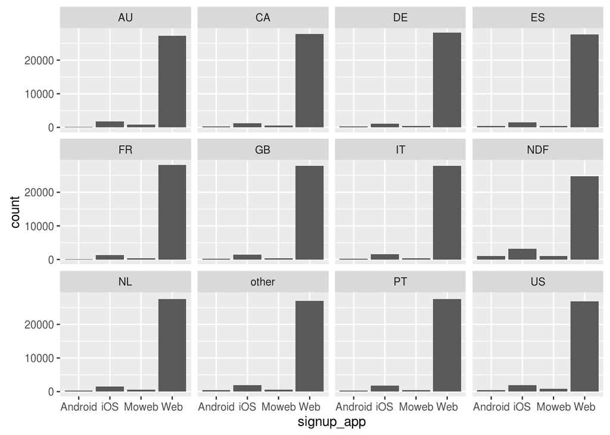

### first_device_type

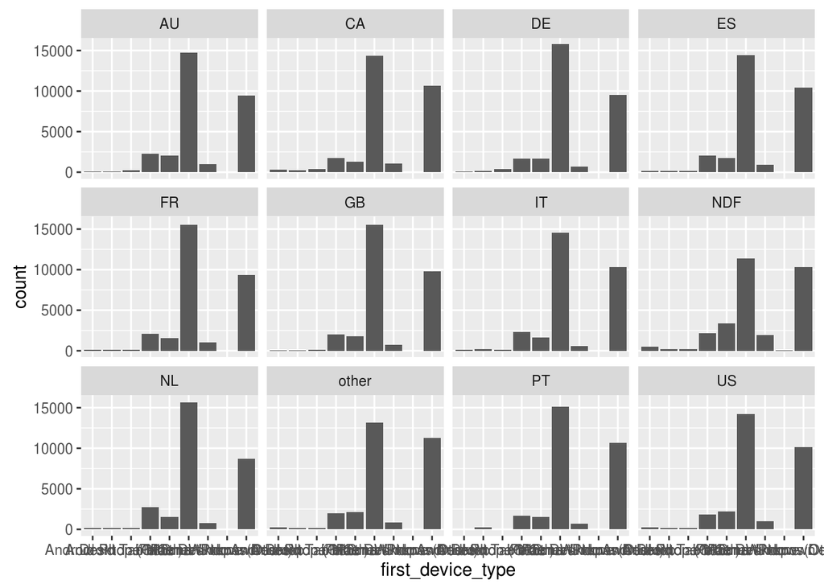

###first_browser

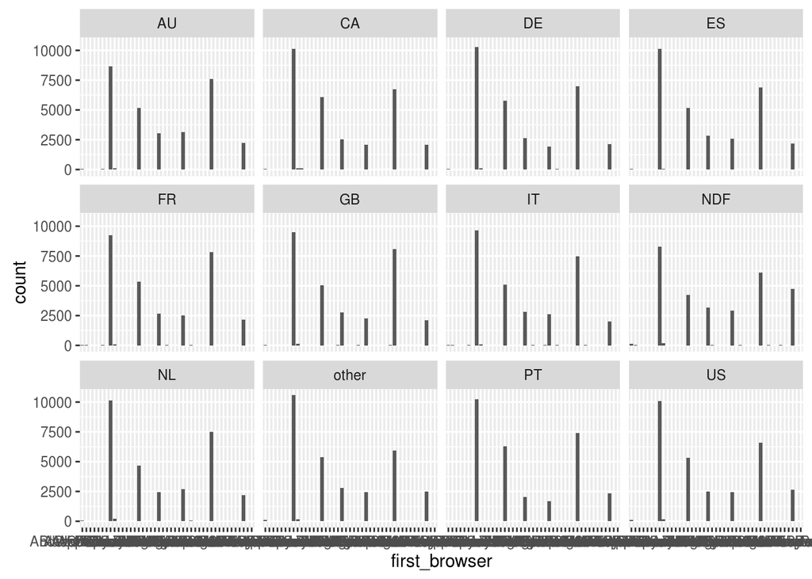

Overall, the variable that might be matter are hour,mon of timestamp_first_active, age of the user and the date_account_created. Other variable do not seem to have pattern that able to predict the first user country_destination because the distribution of the variable data are the same across the country_destination. date_first_booking might be another variable that can be into account but because the testdata provided do not give the date_first_booking, I decide not to use it as feature for the predictive model.